# Differential Gene expression and Preliminary ORA

Jiaming Weng

March 12, 2023

## Introduction

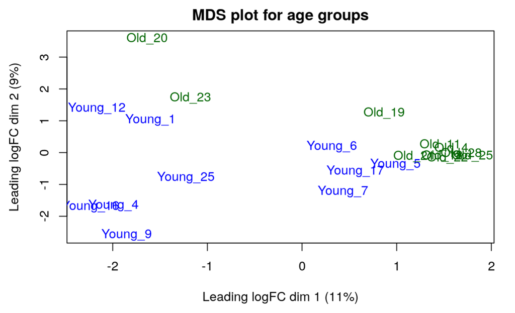

Figure 1. Multidimensional Scaling (MDS) plot with age group coloring, with the clustering of samples based on gene expression data.

```r
knitr::include_graphics("A2_data/MDS_A1.png")
```

## Dependencies and Data Preperation

### Packages

```r
if (! requireNamespace("BiocManager", quietly = TRUE)) {
  install.packages("BiocManager")
}

if (! requireNamespace("limma", quietly = TRUE)) {
  BiocManager::install("limma")
}

if (! requireNamespace("knitr", quietly = TRUE)) {
  install.packages("knitr")
}

if (! requireNamespace("dplyr", quietly = TRUE)) {
  install.packages("dplyr")
}

if (! requireNamespace("edgeR", quietly = TRUE)) {
  BiocManager::install("edgeR")
}

if (! requireNamespace("ComplexHeatmap", quietly = TRUE)) {
  BiocManager::install("ComplexHeatmap")
}

if (! requireNamespace("circlize", quietly = TRUE)) {
  BiocManager::install("circlize")
}

if (!requireNamespace("EnhancedVolcano", quietly = TRUE)) {
    BiocManager::install("EnhancedVolcano")
}
if (!requireNamespace("gprofiler2", quietly = TRUE)) {
    install.packages("gprofiler2")
}

library(Biobase)
library(knitr)
# control variables
library(edgeR)
library(limma)
library(dplyr)
# Volcano
library(EnhancedVolcano)
# heatmap
library(ComplexHeatmap)
library(circlize)
library(gprofiler2)
```

- edgeR: (Robinson, McCarthy, and Smyth 2010)
- ggplot2: (Wickham and Wickham 2007)
- ComplexHeatmap: (Gu, Eils, and Schlesner 2016)
- circlize: (Gu et al. 2014)
- EnhancedVolcano: (Blighe, Rana, and Lewis 2020)
- gprofiler2: (Kolberg et al. 2020)

### load data

- We load the normalized dataset and the sample matrix that contains the study design from Assignment 1.
- The normalized count is has 22 columns (20 samples, one column for emsembl gene id, one column for HUGO symbols).

```r
normalized_count_data <- read.table("A2_data/GSE104406_finalized_normalized_counts",
                                    header = TRUE, row.names = 1,
                                    sep = ",",stringsAsFactors = FALSE,
                                    check.names=FALSE)
normalized_count_data <-normalized_count_data[match(
  unique(normalized_count_data$hgnc_symbol),
  normalized_count_data$hgnc_symbol), ]
kable(normalized_count_data[1:5,1:5], type="html")
```

| ensembl_gene_id | hgnc_symbol | Young_1 | Young_12 | Young_16 |
| --- | --- | --- | --- | --- |
| ENSG00000000003 | TSPAN6 | 13.05679 | 1.7478409 | 21.646904 |
| ENSG00000000419 | DPM1 | 10.99784 | 13.9341762 | 28.931259 |
| ENSG00000000457 | SCYL3 | 55.13985 | 33.3060797 | 11.132694 |
| ENSG00000000460 | C1orf112 | 12.90614 | 0.0971023 | 7.971558 |
| ENSG00000000938 | FGR | 0.00000 | 4.1753977 | 1.374407 |

- The sample matrix that contains our study design:
  - Each sample will have `age_group`, `patient`, and `age` attribute:
  - `age_group` denotes the age group of the sample donor.
  - `patient` is an unique id.
  - `gender` information is also included, “M” for male and “F” for female.

```r
samples <- read.table("A2_data/GSE104406_samples",
                      header = TRUE,sep = ",",
                      stringsAsFactors = FALSE,
                      check.names=FALSE)
kable(samples[5:15, ],  format = "html")
```

|  |  | Var.1 | age_group | patient | gender |
| --- | --- | --- | --- | --- | --- |
| 5 | 5 | Young_25 | Young | 25 | M |
| 6 | 6 | Young_4 | Young | 4 | F |
| 7 | 7 | Young_5 | Young | 5 | M |
| 8 | 8 | Young_6 | Young | 6 | M |
| 9 | 9 | Young_7 | Young | 7 | F |
| 10 | 10 | Young_9 | Young | 9 | M |
| 11 | 11 | Old_11 | Old | 11 | F |
| 12 | 12 | Old_18 | Old | 18 | F |
| 13 | 13 | Old_19 | Old | 19 | F |
| 14 | 14 | Old_21 | Old | 21 | M |
| 15 | 15 | Old_22 | Old | 22 | F |

## Differential Gene Expression Analysis

### Model Design

- First, we define a design matrix.
- We will use Young group as the control group (reference level) and gives it an indicator variable: 0, while denoting the Old group as 1.
- We also want to take into account that gender can be important factor, set “M” which is male as the reference level to see the impact of female to the model.

```r
# refactor reference level for gender
samples$gender <- relevel(as.factor(samples$gender), ref = "M")

# refactor reference level for age group
samples$age_group <- relevel(as.factor(samples$age_group), ref = "Young")

# Design matrix for 2 factors
model_design <- model.matrix(~  samples$gender + samples$age_group)
kable(model_design[5:15,],type="html")
```

|  | (Intercept) | samples$genderF\| samples$age_groupOld |  |
| --- | --- | --- | --- |
| 5 | 1 | 0 | 0 |
| 6 | 1 | 1 | 0 |
| 7 | 1 | 0 | 0 |
| 8 | 1 | 0 | 0 |
| 9 | 1 | 1 | 0 |
| 10 | 1 | 0 | 0 |
| 11 | 1 | 1 | 1 |
| 12 | 1 | 1 | 1 |
| 13 | 1 | 1 | 1 |
| 14 | 1 | 0 | 1 |
| 15 | 1 | 1 | 1 |

- Then we use edgeR package which tests differential expression using a fitted linear model.
- We get the DEGlist on the main factor we want to investigate: age group.

```r
# filter low counts noise, comparing 10 samples to 10 samples
counts <- normalized_count_data[,3: ncol(normalized_count_data)]

d <- DGEList(counts = counts, group = samples$age_group)
d <- calcNormFactors(d)
```

### Egligibility: Mean-variance Plot

- In order to fit a linear model, our dataset must be negative binomial distribution.
- We calculate dispersion, then use MV plot to check our assumption and estimates the global variation across the samples.

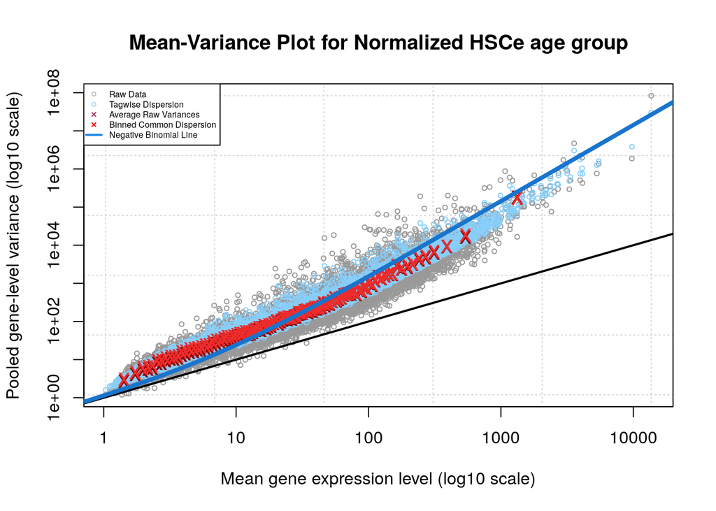

```r
# dispersion
d <- estimateDisp(d, model_design)

# egdeR plot
plotMeanVar(d,
            show.raw.vars = TRUE,
            show.tagwise.vars=TRUE,
            show.ave.raw.vars = TRUE,
            NBline=TRUE,
            show.binned.common.disp.vars = TRUE,
            main = "Mean-Variance Plot for Normalized HSCe age group")

legend("topleft",
       legend=c("Raw Data", "Tagwise Dispersion", "Average Raw Variances",
                "Binned Common Dispersion", "Negative Binomial Line"),
       col = c("grey", "lightblue", "maroon", "red", "dodgerblue2"),
       pch=c(1,1,4,4,NA),
       lty=c(0,0,0,0,1),
       lwd=c(1,1,1,1,2),
       cex=0.5)
```

### p-value and testing

- We calculate the p-value for each gene.
- First, set up an expression matrix and use limma package to obtain an ExpressionSet object for downstream analysis.

```r
# Expression matrix
expressionMatrix <- as.matrix(log2(counts))

rownames(expressionMatrix) <- normalized_count_data$ensembl_gene_id
colnames(expressionMatrix) <- colnames(counts)

minimalSet <- ExpressionSet(assayData=expressionMatrix)

# simple model
fit <- lmFit(minimalSet, model_design)
```

- We use empirical Bayes to compute differential expression for each gene using the model we designed
- Benjamni-hochberg method is chosen to correct the p-value for multiple hypothesis testing.

```r
fit2 <- eBayes(fit, trend=TRUE)

# top-hits
top_hits <- topTable(fit2,
                     coef=ncol(model_design),
                     adjust.method = "BH", # adjust for multiple test, Benjamni - hochberg
                     number = nrow(expressionMatrix))
# used RNA seq and add ids and names to the topfit table
output_hits <- merge(normalized_count_data[,1:2],
                     top_hits,
                     by.y=0,by.x=1,
                     all.y=TRUE)
# rank by pvalue
output_hits <- output_hits[order(output_hits$P.Value),]
kable(output_hits[1:10,2:8],type="html",row.names = FALSE)
```

| hgnc_symbol | logFC | AveExpr | t | P.Value | adj.P.Val | B |
| --- | --- | --- | --- | --- | --- | --- |
| LMNA | -4.097511 | 6.312180 | -9.082266 | 0.0e+00 | 0.0000217 | 11.308933 |
| PDE4B | -3.234269 | 5.924464 | -7.579124 | 1.0e-07 | 0.0003369 | 8.290948 |
| MYADM | -1.898724 | 6.862784 | -7.242861 | 1.0e-07 | 0.0005042 | 7.566796 |
| ADGRE5 | -1.477411 | 6.385094 | -6.993695 | 2.0e-07 | 0.0005619 | 7.019145 |
| FOSL2 | -2.478418 | 8.143715 | -6.989272 | 2.0e-07 | 0.0005619 | 7.009342 |
| LDLR | -3.136503 | 6.084444 | -6.747628 | 4.0e-07 | 0.0008509 | 6.469401 |
| IFIT3 | 2.573467 | 4.133991 | 6.261197 | 1.3e-06 | 0.0024766 | 5.358228 |
| LRIF1 | 2.037773 | 4.593986 | 6.175755 | 1.6e-06 | 0.0026930 | 5.159934 |
| USP42 | -1.428866 | 5.714316 | -6.045344 | 2.3e-06 | 0.0030513 | 4.855623 |
| RPL23AP7 | 5.325263 | 2.470170 | 6.005381 | 2.5e-06 | 0.0030513 | 4.761984 |

- We set the threshold p-value < 0.05 and obtain the number of genes passed the test.

```r
(p <- length(which(output_hits$P.Value < 0.05)))
```

```
## [1] 2761
```

- After adjustion, now less genes pass the threshold of 0.05.

```r
(adj_p <- length(which(output_hits$adj.P.Val < 0.05)))
```

```
## [1] 562
```

### Volcano plot

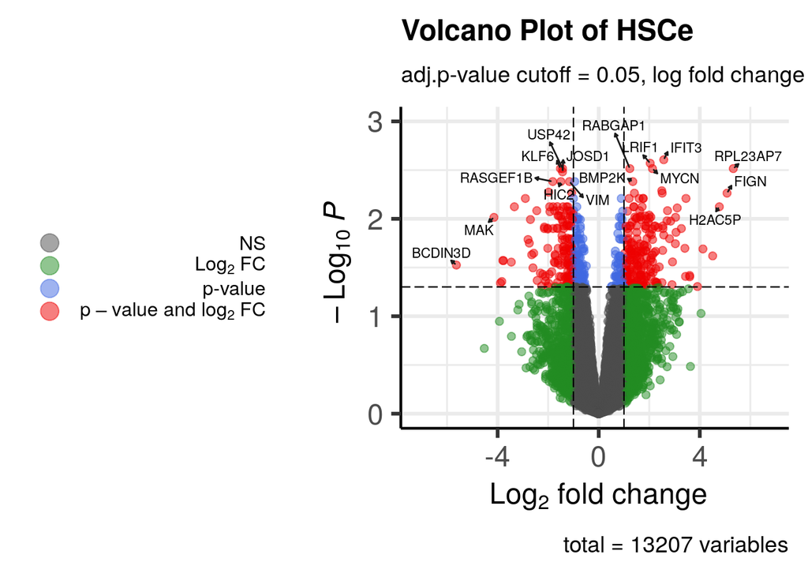

Figure 2. Volcano plot for the top differentially expressed genes passed 0.05 P-value threshold and with absolute Log fold change greater 1. The top hits labeled with the corresponding HUGO gene symbels.

```r
volcano_obj <- data.frame(
    "HGNC_Symbol" = output_hits$hgnc_symbol,
    "logFC" = output_hits$logFC,
    "adj.P.Val" = output_hits$adj.P.Val
)

# plot with package EnhancedVolcano
EnhancedVolcano(volcano_obj,
  lab = volcano_obj$HGNC_Symbol,
  x = 'logFC',
  pCutoff = 0.05,
  y = 'adj.P.Val',
  drawConnectors = TRUE,
  legendPosition = 'left',
  labSize = 3.0,
  legendLabSize = 12,
  title = "Volcano Plot of HSCe",
  subtitle = "adj.p-value cutoff = 0.05, log fold change cutoff=1",
  ylim = c(0,3)
)
```

### Heatmap

- First we want to investigate the gene expression change for the top hits, we will visualize this with a heatmap.

```r
top_hits <- output_hits$hgnc_symbol[output_hits$adj.P.Val < 0.05 & abs(output_hits$logFC) > 1]
heatmap_matrix <- counts[normalized_count_data$hgnc_symbol %in% top_hits,]
rownames(heatmap_matrix) <- counts$hgnc_symbol
colnames(heatmap_matrix) <- colnames(counts)

# Then we normalize and rescale the matrix around the mean
heatmap_matrix <- t(scale(t(heatmap_matrix)))
```

```r
# define the 3 colors used
heatmap_col = colorRamp2(c(min(heatmap_matrix),
                           0,
                           max(heatmap_matrix)),
                         c("blue", "white", "red"))
```

```r
current_heatmap <- Heatmap(as.matrix(heatmap_matrix),
      show_row_dend = TRUE,show_column_dend = TRUE,
      col=heatmap_col,show_column_names = TRUE,
      show_row_names = FALSE,show_heatmap_legend = TRUE)
```

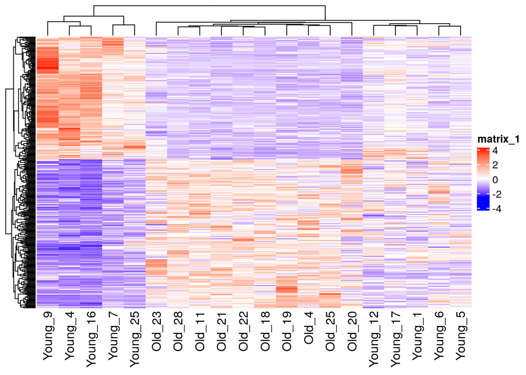

Figure 3. Heatmap for the top differentially expressed genes passed 0.05 P-value threshold. There are clearly clusters on both up and down regulated genesclearly cluster on both up and down regulated genes

```r
current_heatmap
```

- The heat map shows clearly cluster on both distinct up and down regulated genes in different age groups with a reverse trend, which suggests differentially expressed genes.

## Thresholded over-representation analysis

### Expression of samples

- We run a threshold gene set enrichment analysis on the identified up- and down- regulated genes with the gprofiler2 package.

### Up-regulated genes

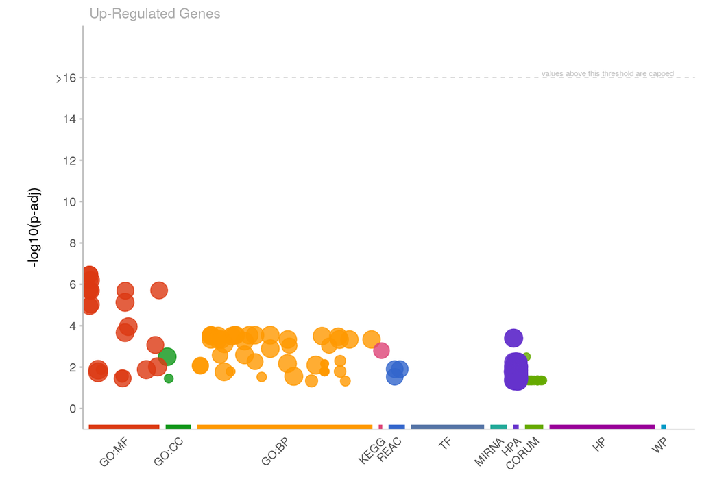

Figure 4. Dot plot for up-regulated thresholded gene list, where top significant pathways that were identified in multiple databases.

```r
up_hits <- output_hits$hgnc_symbol[output_hits$adj.P.Val < 0.05 & output_hits$logFC > 1]
gostres <- gost(query = up_hits,
                organism = "hsapiens",
                ordered_query = FALSE,
                multi_query = FALSE, significant = TRUE, exclude_iea = FALSE,
                measure_underrepresentation = FALSE, evcodes = FALSE,
                user_threshold = 0.05, correction_method = "fdr",
                domain_scope = "annotated", custom_bg = NULL,
                numeric_ns = "", sources = NULL, as_short_link = FALSE)
gostres$result$query <- "Up-Regulated Genes"
gostplot(gostres, interactive = F, )
```

- We then use the result from GO:BP for further enrichment analysis.

```r
bp <- gostres$result[gostres$result$source == "GO:BP", ]
sum(bp$significant==TRUE)
```

```
## [1] 44
```

- There are 44 significant pathways returned
- We use a dot plot from ggplot2 to visualize the result of the enrichment analysis.

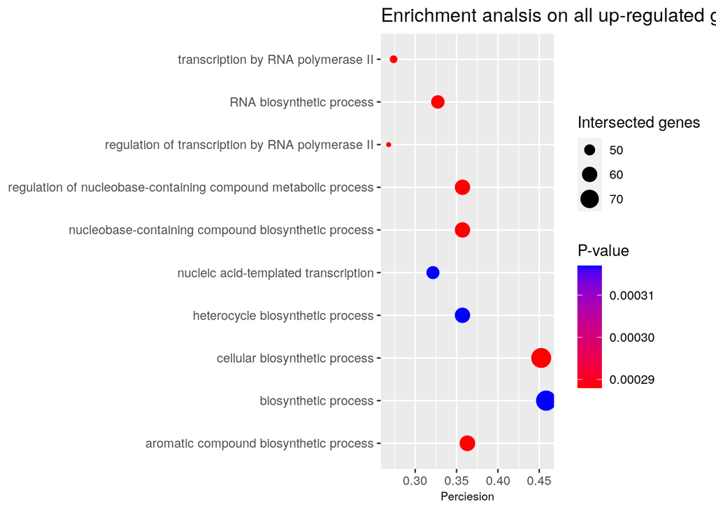

```r
ggplot(bp[1:10,]) +
  geom_point(aes(
    x = precision,
    color = p_value,
    y = term_name,
    size = intersection_size)) +
  theme(axis.title.x = element_text(size = 8),
        axis.title.y = element_text(size = 8)) +
  scale_color_gradient(low = "red", high = "blue") +
  labs(x = "Perciesion",
       color = "P-value",
       size = "Intersected genes",
       y = NULL,
       title = "Enrichment analsis on all up-regulated genes")
```

- The result of the enrichment analysis shows a enrichment in the biosynthetic pathways, which is expected as we are investigating the impact of age on the genomic functions of HSCe.The up-regulated expression of biosynthetic-process related genes verifies that the factor age may contribute to increased risk of myeloid malignancies.
- Interestingly, research shows that histone modifications can impact RNA polymerase pathways by either promoting or inhibiting transcription, because histone modifications play an essential role in regulating gene expression by controlling access to the underlying DNA. (Tanny 2015)

### Down-regulated genes

- The top down-regulated genes are seleced

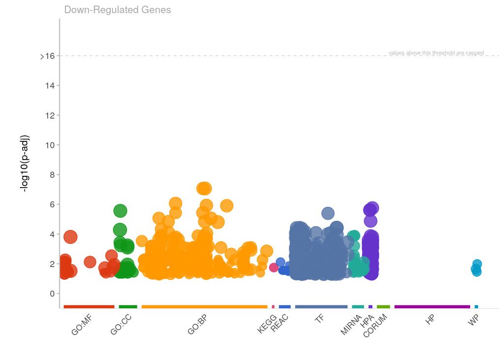

Figure 6. Dot plot for down-regulated thresholded gene list, where top significant pathways that were identified in multiple databases.

```r
down_list <- output_hits$hgnc_symbol[output_hits$adj.P.Val < 0.05 & output_hits$logFC < -1]
gostres <- gost(query = down_list,
                organism = "hsapiens",
                ordered_query = FALSE,
                multi_query = FALSE, significant = TRUE, exclude_iea = FALSE,
                measure_underrepresentation = FALSE, evcodes = FALSE,
                user_threshold = 0.05, correction_method = "fdr",
                domain_scope = "annotated", custom_bg = NULL,
                numeric_ns = "", sources = NULL, as_short_link = FALSE)
gostres$result$query <- "Down-Regulated Genes"
gostplot(gostres, interactive = F, )
```

- We then use the result from GO:BP for further enrichment analysis.

```r
bp_down <- gostres$result[gostres$result$source == "GO:BP", ]
sum(bp_down$significant==TRUE)
```

```
## [1] 216
```

- There are 216 significant pathways returned
- We use a dot plot from ggplot2 to visualize the result of the enrichment analysis.

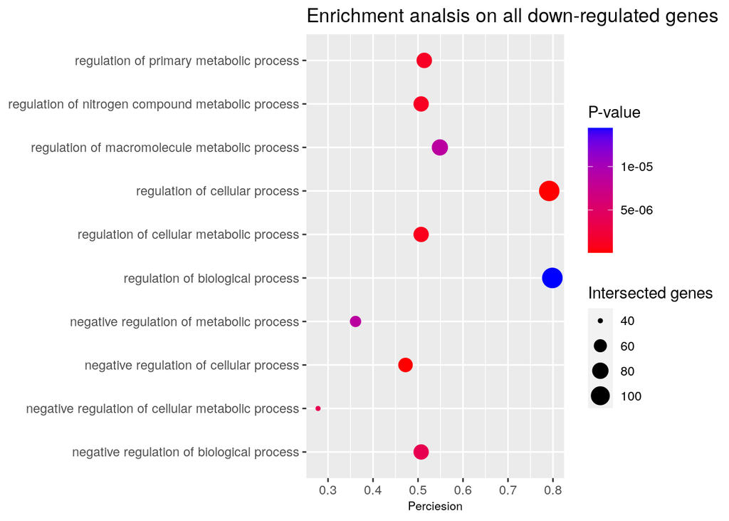

```r
ggplot(bp_down[1:10,]) +
  geom_point(aes(
    x = precision,
    color = p_value,
    y = term_name,
    size = intersection_size)) +
  theme(axis.title.x = element_text(size = 8),
        axis.title.y = element_text(size = 8)) +
  scale_color_gradient(low = "red", high = "blue") +
  labs(x = "Perciesion",
       color = "P-value",
       size = "Intersected genes",
       y = NULL,
       title = "Enrichment analsis on all down-regulated genes")
```

- The result of the enrichment analysis on the down-regulated genes shows a enrichment in the metabolic pathways, which is expected as we are investigating the impact of age on the genomic functions of HSCe.The down-regulated expression of metabolic-process related genes again verifies that the factor age may contribute to increased risk of myeloid malignancies.

### Whole list

- The top hit genes are seleced

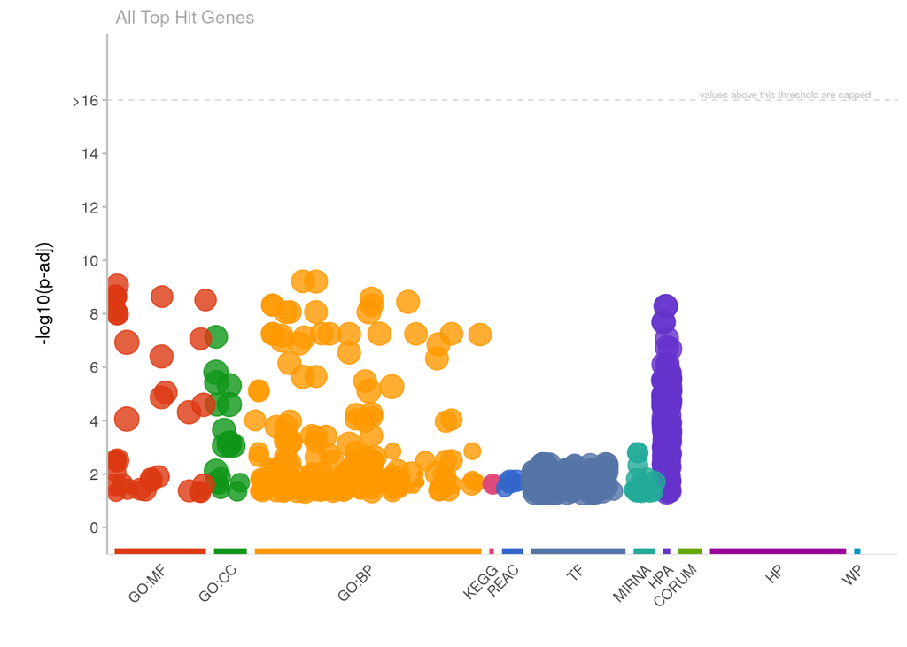

Figure 8. Dot plot for all thresholded gene list, where top significant pathways that were identified in multiple databases.

```r
gostres_all <- gost(query = top_hits,
                organism = "hsapiens",
                ordered_query = FALSE,
                multi_query = FALSE, significant = TRUE, exclude_iea = FALSE,
                measure_underrepresentation = FALSE, evcodes = FALSE,
                user_threshold = 0.05, correction_method = "fdr",
                domain_scope = "annotated", custom_bg = NULL,
                numeric_ns = "", sources = NULL, as_short_link = FALSE)
gostres_all$result$query <- "All Top Hit Genes"
gostplot(gostres_all, interactive = F, )
```

- We then use the result from GO:BP for further enrichment analysis.

```r
bp_all <- gostres_all$result[gostres$result$source == "GO:BP", ]
sum(bp_all$significant==TRUE)
```

```
## [1] 216
```

- There are 216 significant pathways returned
- We use a dot plot from ggplot2 to visualize the result of the enrichment analysis.

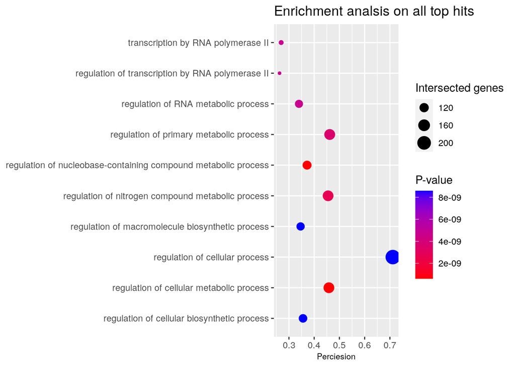

```r
ggplot(bp_all[1:10,]) +
  geom_point(aes(
    x = precision,
    color = p_value,
    y = term_name,
    size = intersection_size)) +
  theme(axis.title.x = element_text(size = 8),
        axis.title.y = element_text(size = 8)) +
  scale_color_gradient(low = "red", high = "blue") +
  labs(x = "Perciesion",
       color = "P-value",
       size = "Intersected genes",
       y = NULL,
       title = "Enrichment analsis on all top hits")
```

## Interpretation

### Differential Gene Expression

**1. Calculate p-values for each of the genes in your expression set. How many genes were significantly differentially expressed? What thresholds did you use and why?**

- 2761 genes were significantly differentially expressed using the thresholds of p <0.05, which is the most common one used for statistical testing.

**2. Multiple hypothesis testing - correct your p-values using a multiple hypothesis correction method. Which method did you use? And Why? How many genes passed correction?**

- Benjamni-hochberg method is chosen to correct the p-value for multiple hypothesis testing, as it provides a good balance between controlling the FDR and maintaining statistical power to detect true positives (i.e. differentially expressed genes). 562 genes passed correction.

**3.Show the amount of differentially expressed genes using an MA Plot or a Volcano plot. Highlight genes of interest.**

- Plots where in the Volcano plot section above.

**4. Visualize your top hits using a heatmap. Do you conditions cluster together? Explain why or why not.**

- Plots where in the Heatmap section above. Our conditions (age group) cluster together because we have up and down regulated genes based on age groups.

### Thresholded over-representation analysis

**1. Which method did you choose and why?**

- We chose the top hit gene lists for both up and town regulated genes seperately, as well as the whole gene list, and sent to g:Profiler to perform the gene set enrichment analysis (GSEA).

**2. What annotation data did you use and why? What version of the annotation are you using? How many genesets were returned with what thresholds?**

- We used multiple annotation data of the latest version(e108_eg55_p17_0254fbf), then restrict to GO:BP.
- 216 genesets where returned in total

### Interpretation

**1. Do the over-representation results support conclusions or mechanism discussed in the original paper?**

- The overall-representation results supports the conclusion in the original paper. They suggest that aging has been shown to have significant effects on the epigenome, with consistent changes observed across different individuals. These changes impact both cytosine and histone modifications and affect critical developmental and cancer pathways. (Adelman et al. 2019) As our results from differential gene expression, genes are differentially expressed between aged and young group, and enrichment analysis shows that the top differentially expressed genes are related with developmental pathways like metabolic and biosynthetic pathway; and RNA polymerase II pathways shown to be related with histone modifications.

**2. Can you find evidence, i.e. publications, to support some of the results that you see. How does this evidence support your results.**

- Yes, as suggested by the reseach of Nakamura-Ishizu et al., during aging, hematopoietic stem cells (HSCs) undergo a transition through multiple hematopoietic sites, which necessitates significant metabolic changes. This suggests that HSCs have the ability to meet the physiological demands of hematopoiesis. Which is consistent with our result that the enrichment analysis gives majorly metabolic pathways. (Nakamura-Ishizu, Ito, and Suda 2020)

Adelman, Emmalee R., Hsuan-Ting Huang, Alejandro Roisman, André Olsson, Antonio Colaprico, Tingting Qin, R. Coleman Lindsley, et al. 2019. “Aging Human Hematopoietic Stem Cells Manifest Profound Epigenetic Reprogramming of Enhancers That May Predispose to Leukemia.” *Cancer Discovery* 9 (8): 1080–1101. https://doi.org/10.1158/2159-8290.CD-18-1474.

Beerman, Isabel, Christoph Bock, Brian S. Garrison, Zachary D. Smith, Hongcang Gu, Alexander Meissner, and Derrick J. Rossi. 2013. “Proliferation-Dependent Alterations of the DNA Methylation Landscape Underlie Hematopoietic Stem Cell Aging.” *Cell Stem Cell* 12 (4): 413–25. https://doi.org/10.1016/j.stem.2013.01.017.

Blighe, K, S Rana, and M Lewis. 2020. “EnhancedVolcano: Publication-Ready Volcano Plots with 667 Enhanced Colouring and Labeling. R Package Version 1.6. 0. 668.” *EnhancedVolcano*.

Gu, Zuguang, Roland Eils, and Matthias Schlesner. 2016. “Complex Heatmaps Reveal Patterns and Correlations in Multidimensional Genomic Data.” *Bioinformatics* 32 (18): 2847–49.

Gu, Zuguang, Lei Gu, Roland Eils, Matthias Schlesner, and Benedikt Brors. 2014. “Circlize Implements and Enhances Circular Visualization in r.” *Bioinformatics* 30 (19): 2811–12.

Kolberg, Liis, Uku Raudvere, Ivan Kuzmin, Jaak Vilo, and Hedi Peterson. 2020. “Gprofiler2–an r Package for Gene List Functional Enrichment Analysis and Namespace Conversion Toolset g: Profiler.” *F1000Research* 9.

Nakamura-Ishizu, Ayako, Keisuke Ito, and Toshio Suda. 2020. “Hematopoietic Stem Cell Metabolism During Development and Aging.” *Dev Cell* 54 (2): 239–55. https://doi.org/10.1016/j.devcel.2020.06.029.

Robinson, Mark D, Davis J McCarthy, and Gordon K Smyth. 2010. “edgeR: A Bioconductor Package for Differential Expression Analysis of Digital Gene Expression Data.” *Bioinformatics* 26 (1): 139–40.

Tanny, Jason C. 2015. “Chromatin Modification by the RNA Polymerase II Elongation Complex.” *Transcription* 5 (5): e988093. https://doi.org/10.4161/21541264.2014.988093.

Wickham, Hadley, and Maintainer Hadley Wickham. 2007. “The Ggplot Package.” *Google Scholar*.